# Data science exam: part 2

Author

[names]

# Part II - 1: Regression

## Data

This part uses the `personality` dataset from the R package `doBy` with recordings of 32 variables describing personality characteristics for 240 people. (see help file for `?personality`)

We focus on the variable `easygon` as the response variable. We split the data in training and test data as follows:

```r
dat <- doBy::personality
set.seed(101) # for reproducibility
i_train <- sample(nrow(dat), .5*nrow(dat))
train <- dat[i_train,]
test <- dat[-i_train,]
```

## Exercise 1

Use `response_plot()` from the **development version of** `doBy` to visualize the relation between the response and the other variables in the data.

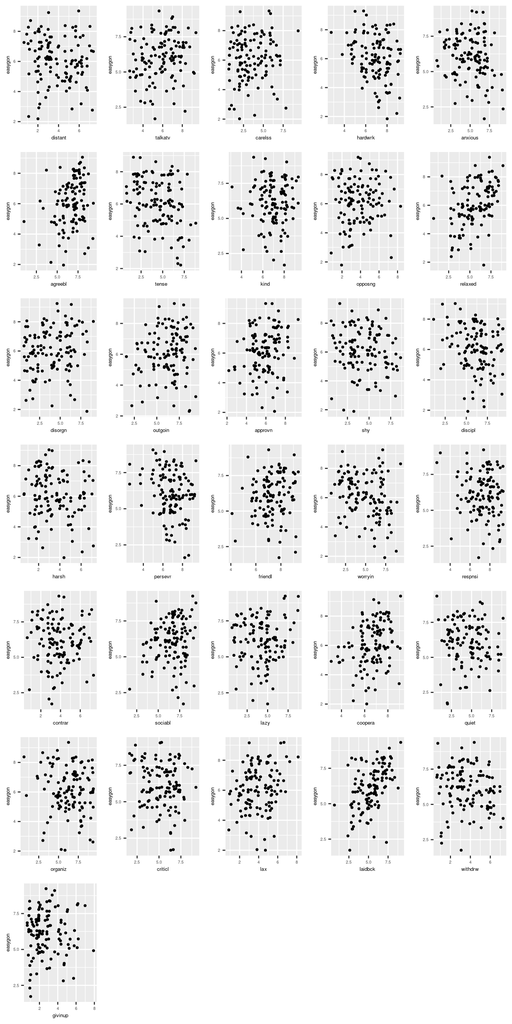

## Exercise 3

Specify a number of prediction models – at least one of each of the following:

1. linear with stepwise selection (`lm` / `step`)
2. regression tree (`rpart`)
3. random forest (`randomForest`)

## Exercise 4

For **one of** the linear models show the estimated coefficients and comment **briefly** on the output (for example, comment on the sign of the estimates).

```
# A tibble: 9 × 5
  term        estimate std.error statistic   p.value
  <chr>          <dbl>     <dbl>     <dbl>     <dbl>
1 (Intercept)  -0.0112    1.24    -0.00906 0.993
2 laidbck       0.366     0.0790   4.63    0.0000100
3 coopera       0.381     0.0988   3.86    0.000192
4 persevr      -0.150     0.0935  -1.60    0.112
5 talkatv       0.178     0.0652   2.72    0.00748
6 givinup       0.197     0.0805   2.45    0.0160
7 relaxed       0.158     0.0843   1.88    0.0632
8 opposng       0.153     0.0724   2.11    0.0372
9 harsh        -0.119     0.0737  -1.61    0.110
```

## Exercise 5

Compare the performance of the fitted models by predicting the values of `easygon` for the test data and show a plot comparing the predictions to the observations from the test data. Also make a table of the RMSE for each model.

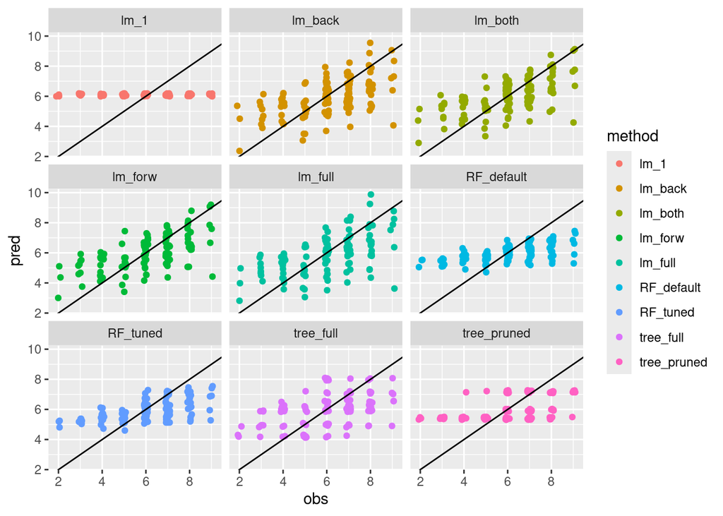

|  | RMSE |
| --- | --- |
| **lm_forw** | 1.35 |
| **lm_both** | 1.35 |
| **RF_tuned** | 1.399 |
| **RF_default** | 1.433 |
| **lm_back** | 1.444 |
| **lm_full** | 1.474 |
| **tree_pruned** | 1.516 |
| **tree_full** | 1.568 |
| **lm_1** | 1.696 |

# Part II - 2: Classification

The dataset `diabetes.csv` is about risk factors for diabetes and contains 768 observations of 9 variables. The response variable is `Outcome` which is binary. The goal is to predict `Outcome` using the other variables. A description of the dataset can be found at https://www.kaggle.com/datasets/mathchi/diabetes-data-set/data

## Exercise 1

Read in and clean the data by detecting unexpected values of some variables, replace the values with `NA` and finally make a data set with only the complete cases.

```r
dim(dat)
```

```
[1] 392   9
```

## Exercise 2

Plot the response against each of the explanatory variables/features and add a smooth line as a *very rough* indication of how the probability of diabetes depends on the individual feature (note the response has to be numeric for the smooth line to work).

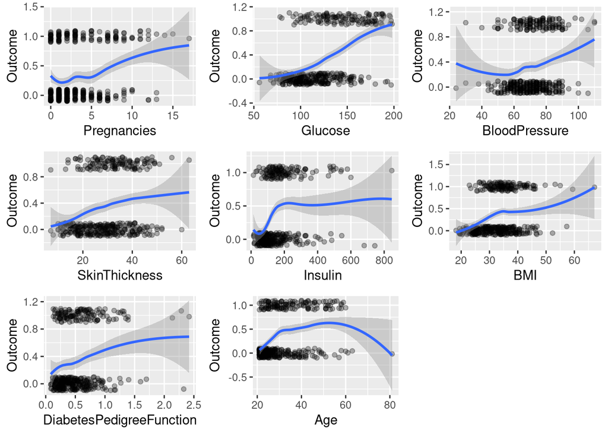

## Exercise 3

Ensure `Outcome` is a `factor` and split the data in a training and test set as follows:

```r
set.seed(202) # for reproducibility
i_train <- sample(nrow(dat), .5*nrow(dat))
train <- dat[i_train,]
test <- dat[-i_train,]
```

Specify a number of classification models and report the corresponding confusion matrix for the test data. You must include at least one of each of the following:

1. logistic regression with stepwise selection (`glm` / `step`)
2. regression tree (`rpart`)
3. random forest (`randomForest`)
4. linear/quadratic discriminant analysis

```
    logreg_full
true   0   1
   0 108  21
   1  30  37
```

```
    logreg_step
true   0   1
   0 110  19
   1  30  37
```

```
    lda
true   0   1
   0 110  19
   1  32  35
```

```
    tree_full
true   0   1
   0 107  22
   1  30  37
```

```
    tree_small
true  0  1
   0 95 34
   1 17 50
```

```
    rf
true   0   1
   0 112  17
   1  31  36
```

```
    rf_tune
true   0   1
   0 110  19
   1  32  35
```